# La deprivación urbana en Chile no es unidimensional

Estructura multivariante de 4.843 zonas censales urbanas: exploración, reducción de dimensiones, inferencia y clasificación

Nicole Gana · Carlos Pizarro · Camila Toloza

2026-08-28

El problema

Dos zonas con el *mismo* índice de deprivación pueden ser *mundos* distintos.

Chile mide la carencia territorial con **índices de una sola dimensión**: un número por zona que ordena de menos a más carenciada. Es cómodo para priorizar, pero obliga a comprimir en una escala fenómenos que quizá no van juntos. Un barrio del centro de Santiago con hacinamiento extremo y población migrante puede recibir la misma nota que una periferia con desempleo y jefatura femenina.

4.843 zonas censales urbanas de Chile, con 11 indicadores sociodemográficos del Censo 2017

4.843

## 01 · ContextoLa base de datos

| Variable | Definición |
| --- | --- |
| Vivienda |  |
| Sin hacinamiento | % de hogares sin hacinamiento |
| Hacinamiento medio | % de hogares con hacinamiento medio |
| Hacinamiento alto | % de hogares con hacinamiento alto |
| Hacinamiento crítico | % de hogares con hacinamiento crítico |
| Índice hacinamiento | Resumen del hacinamiento de la zona |
| Educación |  |
| Escolaridad | Años promedio de escolaridad |
| Empleo |  |
| Desocupación | % de población desocupada |
| Cohesión social |  |
| Población extranjera | % de población extranjera |
| Pob. mayor vive sola | % de población mayor que vive sola |
| Hogares monop. mujer | % de hogares monoparentales con jefa mujer |
| Síntesis |  |
| Índice de deprivación | Índice normalizado (0–1) provisto con la base |

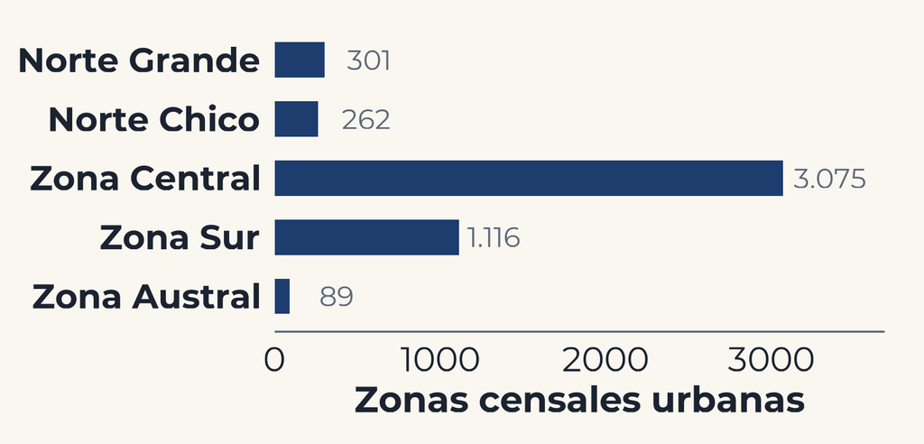

16regiones

56provincias

319comunas

**Se trabaja con 8 de las 11.** Los cuatro porcentajes de hacinamiento suman 100. El índice provisto se reserva como **validación externa**.

## 02 · Pregunta y objetivosQué queremos responder

**¿Basta una sola dimensión para describir la situación socioterritorial de las zonas urbanas de Chile, o existen perfiles distintos que un índice escalar no logra separar?**

Hipótesis 1 La estructura de correlaciones requiere **más de una** componente para representarse adecuadamente.

Hipótesis 2 Existen perfiles territoriales sustantivamente distintos que el índice unidimensional **no distingue**.

Hipótesis 3 La variabilidad es sobre todo **intracomunal**: las divisiones administrativas explican poco.

01 Describir la variabilidad, la asociación y los casos atípicos. → Descriptiva y gráficos

02 Reducir la dimensión e interpretar los ejes obtenidos. → ACP

03 Confirmar y nombrar la estructura latente. → Análisis factorial

04 Contrastar si los territorios difieren. → $T^2$ y MANOVA

05 Construir una tipología de zonas y validarla. → Clustering

06 Relacionar tipología y territorio. → Correspondencias

07 Medir cuánta información pierde el índice. → Clasificación supervisada

## 03 · MetodologíaQué técnica y por qué

| Objetivo | Técnica elegida | También se probó |
| --- | --- | --- |
| Explorar | S, R, Mahalanobis, gráfico de estrellas | Spearman frente a Pearson |
| Reducir la dimensión | Componentes principales sobre R | Kaiser, codo y % de varianza |
| Nombrar la estructura | Factorial · factor principal + Varimax | Máxima verosimilitud; 2 factores |
| Comparar territorios | T² de Hotelling y MANOVA | Λ de Wilks y traza de Pillai |
| Agrupar zonas | No supervisada · Ward, k = 4 | 4 enlaces, k-medias, CLARA, k de 2 a 8 |
| Relacionar con el territorio | Correspondencia simple | Perfiles fila y columna |
| Medir la predictibilidad | Regresión logística + curva ROC | 8 variables frente a sólo el índice |

**Ninguna decisión se tomó por defecto.** En total se evaluaron 2 medidas de correlación, 2 métodos de estimación factorial, **5 métodos de enlace**, 3 algoritmos de conglomerados, 7 valores de $k$ y 2 conjuntos de predictores.

## 04 · ExploraciónDescriptiva y medidas de variabilidad

| Variable | Media | Mediana | DE | CV | Mínimo | Máximo | Asimetría |
| --- | --- | --- | --- | --- | --- | --- | --- |
| Hacinamiento medio | 4.58 | 4.30 | 2.69 | 0.59 | 0.00 | 22.22 | 0.64 |
| Hacinamiento alto | 1.01 | 0.79 | 0.95 | 0.93 | 0.00 | 16.67 | 2.79 |
| Hacinamiento crítico | 0.69 | 0.38 | 1.06 | 1.53 | 0.00 | 17.39 | 5.37 |
| Desocupación | 5.21 | 5.19 | 1.52 | 0.29 | 0.00 | 18.42 | 0.39 |
| Escolaridad | 11.43 | 11.09 | 1.81 | 0.16 | 7.18 | 16.40 | 0.67 |
| Hogares monop. mujer | 10.86 | 10.92 | 2.81 | 0.26 | 0.00 | 26.05 | −0.12 |
| Pob. mayor vive sola | 2.47 | 2.24 | 1.50 | 0.61 | 0.00 | 28.57 | 2.67 |
| Población extranjera | 4.50 | 2.16 | 6.87 | 1.53 | 0.00 | 70.59 | 3.62 |

72.2varianza total  
(traza de S)

1522varianza generalizada  
|S|

0.967redundancia 1 − |R|

Qué mide cada una, y qué decidimos La **traza** suma por separado; el **determinante de S** toma en cuenta que las variables van juntas; el de $\mathbf{R}$ se lee al revés, como **información repetida**.  
Escalas incomparables ⟶ **estandarizar**.  
Redundancia 0.967 ⟶ **hay estructura que reducir**.

## La estructura de asociación

Exploración · Matriz de correlaciones

Correlación lineal sobre los valores

Las dos coinciden en lo estructural

Lo esperable Hacinamiento medio y alto ($0{,}73$) y desocupación  
($0{,}50$) frente a escolaridad ($-0{,}65$):  
el núcleo clásico de la carencia.

Lo que no encaja Hacinamiento crítico va con población extranjera  
(**$0{,}52$**), pero ésta va con **más** escolaridad ($+0{,}37$).  
Ese patrón **no cabe** en un solo eje de carencia.

Y es una asociación de cola 0.11 en el 80 % de zonas con menos extranjeros;  
0.53 en el 20 % superior. Existe **sólo donde hay presencia migrante**.

## Perfiles territoriales: gráfico de estrellas

Análisis gráfico multivariante

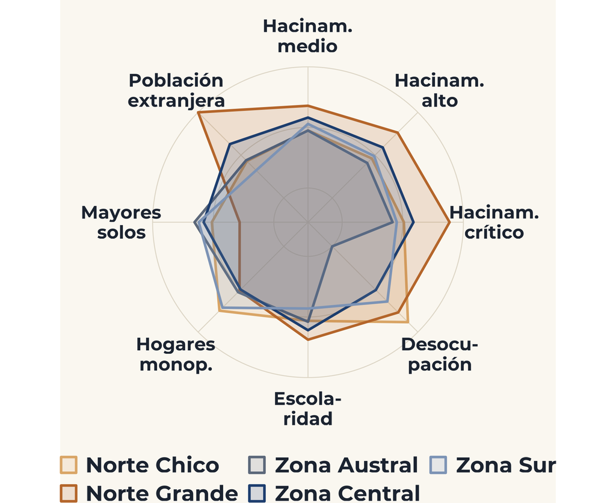

Medias de las variables estandarizadas por macrozona.  
El radio crece con el valor de la variable.

Si un solo número bastara para ordenarlas, los polígonos serían versiones agrandadas unos de otros. **Y no lo son.**

## Distancias, casos atípicos y normalidad

Distancia de Mahalanobis y normalidad multivariante

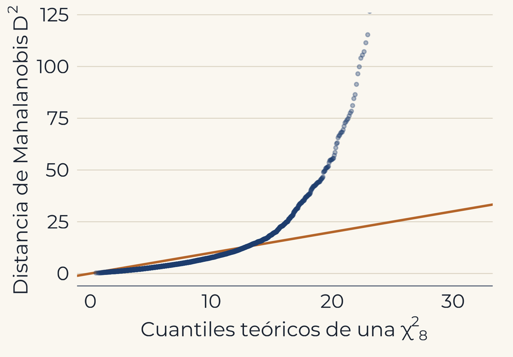

Si los datos fueran normales, los puntos caerían **sobre la recta**. La cola se despega: hay muchas más zonas extremas de las que la normal admite.

8.1 %de las zonas se sale de lo que la normal permite;  
debería ser 5 %

179zonas rarísimas: la normal admitiría 5

H₀ los datos siguen una **normal multivariante**

H₁ no la siguen

**Test de Mardia:**  
Vía curtosis ($b_{2,p}$): 429.5 (esperado 80)  
Vía asimetría ($\chi^2_{120}$): 85.969, $p$ < 2e-16

Se rechaza H₀ por las dos vías.

Y aun así, no eliminamos ningún atípico Las zonas extremas **son** el fenómeno que estudiamos.

## 05 · Componentes principales¿Cuántas dimensiones hacen falta?

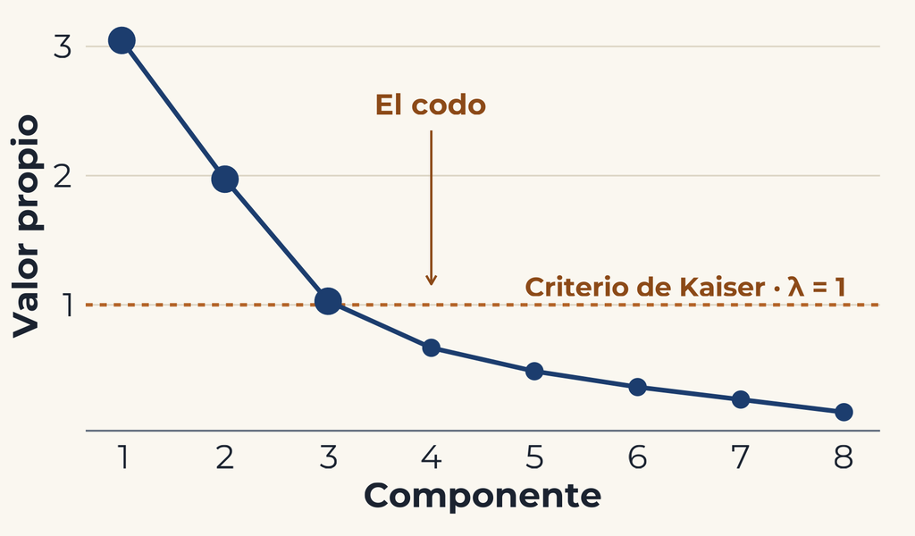

| Componente | Valor propio | % varianza | % acumulado |
| --- | --- | --- | --- |
| CP1 | 3.047 | 38.085 | 38.085 |
| CP2 | 1.972 | 24.655 | 62.740 |
| CP3 | 1.028 | 12.850 | 75.591 |
| CP4 | 0.667 | 8.341 | 83.932 |
| CP5 | 0.486 | 6.075 | 90.006 |

Tres criterios, tres componentes Kaiser ($\lambda_3=$ 1.03), el codo en la cuarta y el **75.6 %** de varianza: los tres coinciden.

H₀ $\mathbf{R}=\mathbf{I}$ · las variables son incorrelacionadas: **no hay nada que reducir**

H₁ $\mathbf{R}\neq\mathbf{I}$ · **hay estructura de correlación** que un ACP puede resumir

Esfericidad de Bartlett: $\chi^2_{28}=$ 16.524, $p$ < 2e-16 · KMO $=$ 0.699 (admisible, $>0{,}5$)

Se rechaza H₀: reducir la dimensión está justificado.

## Los tres ejes y su interpretación

ACP · Correlaciones variable–componente y biplot

| Variable | CP1 | CP2 | CP3 |
| --- | --- | --- | --- |
| Hacinamiento medio | 0.903 | 0.032 | −0.069 |
| Hacinamiento alto | 0.830 | 0.296 | 0.010 |
| Hacinamiento crítico | 0.541 | 0.675 | 0.032 |
| Desocupación | 0.681 | −0.192 | 0.279 |
| Escolaridad | −0.756 | 0.386 | −0.299 |
| Hogares monop. mujer | 0.305 | −0.689 | −0.230 |
| Pob. mayor vive sola | −0.343 | 0.141 | 0.881 |
| Población extranjera | 0.048 | 0.865 | −0.157 |

CP1 · Deprivación socioeconómica — 38.1 % Hacinamiento y desocupación frente a escolaridad.

CP2 · Hacinamiento crítico migrante — 24.7 % Extranjeros y hacinamiento crítico, **con escolaridad positiva**.

CP3 · Envejecimiento residencial — 12.9 % Casi puro: población mayor que vive sola.

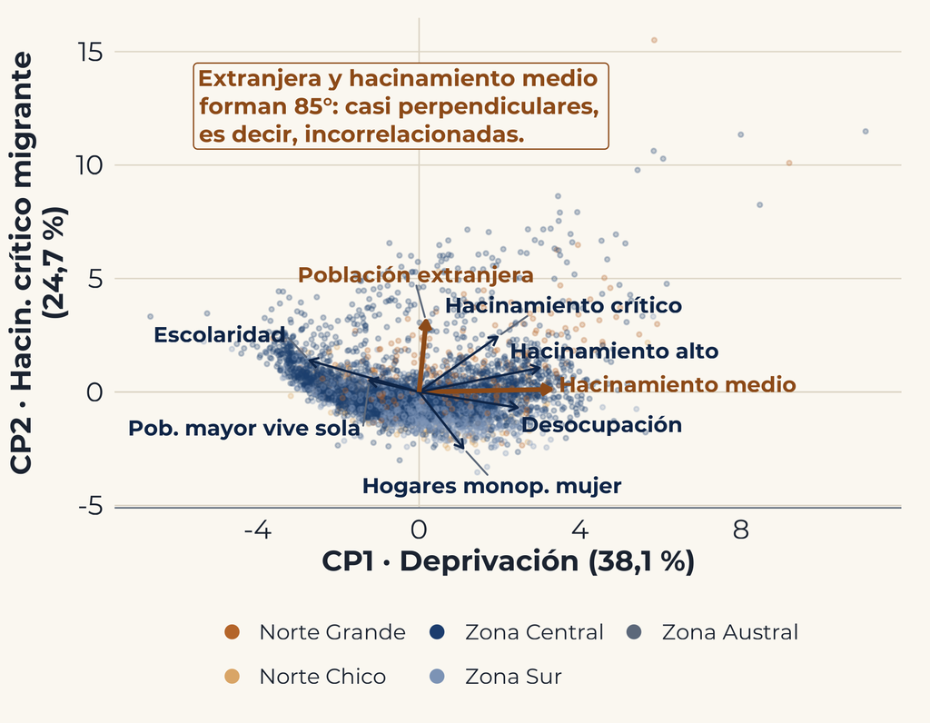

## ¿Qué ve y qué no ve el índice oficial?

ACP · Validación externa

0.907correlación CP1 – índice

-0.337correlación CP2 – índice

0.155correlación CP3 – índice

**Coincide en lo que mide.** La CP1 correlaciona 0.907 con el índice, sin haberlo usado. Mide bien la carencia clásica.

**No ve la segunda dimensión.** La CP2 vale el 24.7 % de la varianza y es ajena al índice ($r =$ -0.337).

**Una escala no puede contener varios fenómenos independientes entre sí.**

## 06 · Análisis factorialSeparar lo común de lo específico

| Variable | F1 | F2 | F3 | Comunalidad | Var. específica |
| --- | --- | --- | --- | --- | --- |
| Hacinamiento medio | 0.800 | 0.183 | −0.384 | 0.821 | 0.179 |
| Hacinamiento alto | 0.705 | 0.400 | −0.209 | 0.701 | 0.299 |
| Hacinamiento crítico | 0.406 | 0.676 | −0.021 | 0.621 | 0.379 |
| Desocupación | 0.580 | −0.054 | −0.099 | 0.350 | 0.650 |
| Escolaridad | −0.884 | 0.307 | −0.022 | 0.875 | 0.125 |
| Hogares monop. mujer | 0.239 | −0.462 | −0.343 | 0.389 | 0.611 |
| Pob. mayor vive sola | −0.105 | 0.017 | 0.632 | 0.411 | 0.589 |
| Población extranjera | −0.107 | 0.812 | −0.020 | 0.671 | 0.329 |

Factor principal, no máxima verosimilitud ML supone normalidad multivariante y Mardia la rechazó.  
El factor principal es descriptivo y no la exige.

| Factor | % varianza | % acumulado |
| --- | --- | --- |
| F1 · Deprivación socioeconómica | 31.24 | 31.24 |
| F2 · Hacinamiento crítico migrante | 20.25 | 51.49 |
| F3 · Envejecimiento residencial | 8.99 | 60.48 |

Dos técnicas, la misma estructura El factorial **reproduce** los tres ejes del ACP con cargas más nítidas. Criterios distintos, mismo resultado:  
la estructura es del fenómeno, no del método.

Varimax separa lo que el ACP mezclaba El hacinamiento **crítico** (F2) queda aparte del medio y alto (F1). La sobreocupación extrema no es «más» del mismo problema: es **otro**.

## 07 · Inferencia multivariada¿Difieren los territorios?

$T^2$ de Hotelling · Metropolitana frente al resto

H₀ $\boldsymbol{\mu}_{\text{RM}}=\boldsymbol{\mu}_{\text{resto}}$

H₁ $\boldsymbol{\mu}_{\text{RM}}\neq\boldsymbol{\mu}_{\text{resto}}$

$T^2=$ 1.559 → $F_{8,\,4.834}=$ 194.6, $p$ < 2e-16

Se rechaza H₀ · $n_1=$ 1.859 zonas de la RM

Las cinco variables donde más difiere la RM

| Variable | RM | Resto | Diferencia |
| --- | --- | --- | --- |
| Población extranjera | 7.52 | 2.61 | 4.90 |
| Hogares monop. mujer | 10.16 | 11.29 | −1.12 |
| Hacinamiento medio | 5.10 | 4.26 | 0.84 |
| Escolaridad | 11.91 | 11.13 | 0.78 |
| Pob. mayor vive sola | 2.07 | 2.71 | −0.64 |

MANOVA · las cinco macrozonas

H₀ $\boldsymbol{\mu}_1=\boldsymbol{\mu}_2=\dots=\boldsymbol{\mu}_5$

H₁ al menos un vector de medias difiere

$\Lambda=|\mathbf{W}|/|\mathbf{W}+\mathbf{B}|=$ 0.743 → $F_{32,\,17.817}=$ 46.7, $p$ < 2e-16

Se rechaza H₀  
La traza de Pillai ($0.277$) concluye lo mismo

+4.9puntos de extranjeros: la mayor diferencia de la RM

Significancia estadística vs. Relevancia Un $\Lambda = 0.743$ revela que el **74.3 %** de las diferencias entre zonas ocurre **independiente de la macrozona**. Con $n = 4.843$, el test siempre dará “significativo”. Lo crucial es notar que el tamaño del efecto ($\eta^2_p$) es muy bajo.

## Significación no es relevancia: dónde está la variabilidad

Elipsoides bivariados · Descomposición de la varianza

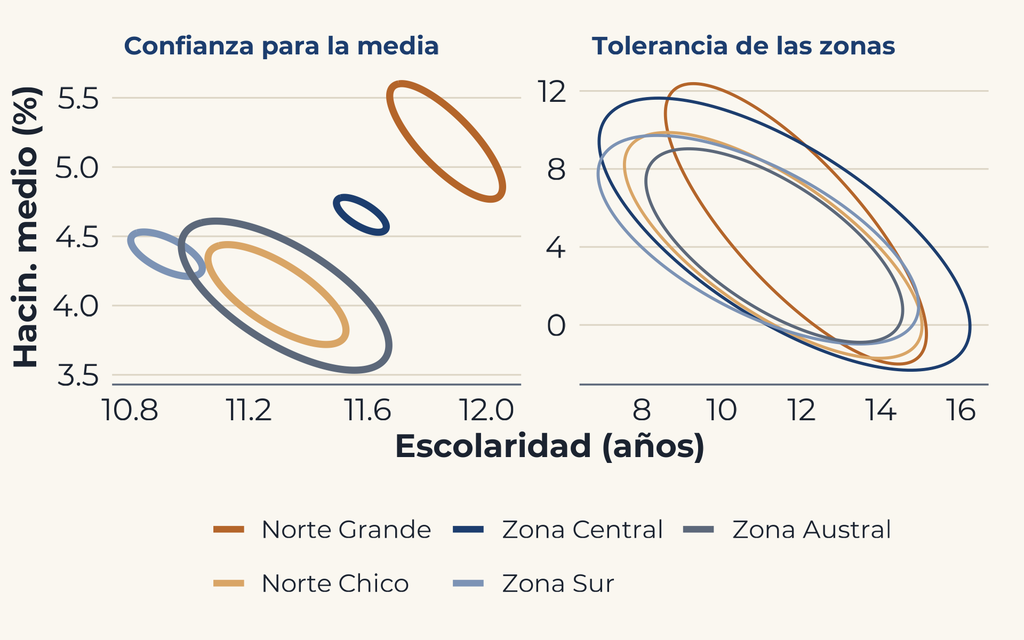

- CP1
- CP2
- CP3

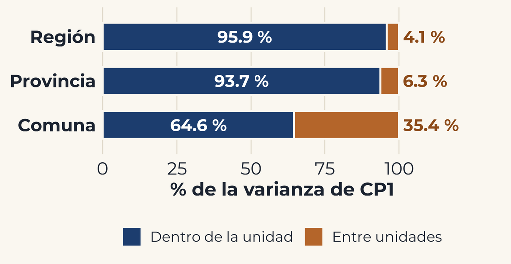

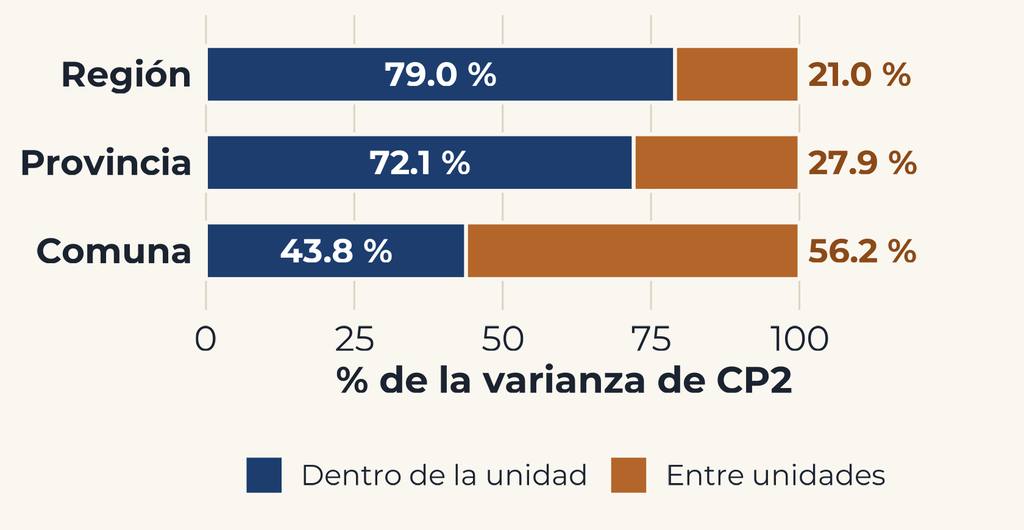

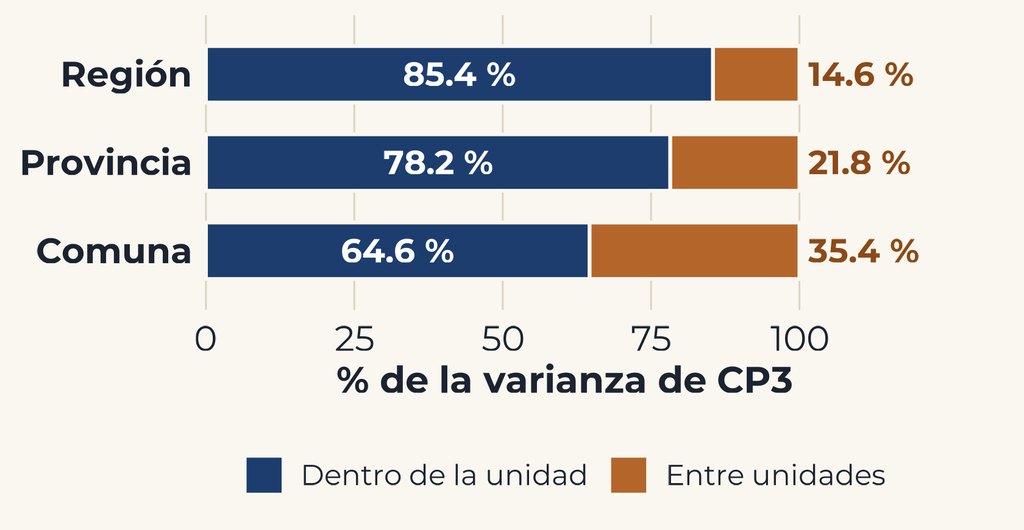

**Las medias difieren; las zonas no.** Incluso dentro de la **comuna** queda el **64.6 %** de la variabilidad (CP1). La escala del fenómeno es **submunicipal**.

## 08 · ClusteringConstruir la tipología

Qué hace y cómo se lee Une las dos zonas más parecidas, una y otra vez. La **altura** de la unión es lo distintas que eran; **cortando** a una cierta altura visualizamos el número de ramas (grupos).

Por qué gana Ward Los métodos clásicos sufren de **encadenamiento**. Si los cortas, no sugieren una partición equilibrada y útil. Sólo **Ward** logra un agrupamiento robusto para la tipología, sin necesidad de forzar los cortes.

## ¿Cuántos grupos? Explorador de $k$

Validación interna · silueta y Dunn frente a $k$

Los grupos se forman con **las ocho variables**. El mapa sólo los **dibuja** sobre las dos primeras componentes, que es el plano donde más se ven.

Grupos **4**

Perfil de siluetas · una barra por zona

—silueta media

—índice de Dunn

—zonas en el grupo menor

—% extranjeros en ese grupo

Por qué cuatro grupos Hasta $k=3$ el grupo menor son 731 zonas con 12,7 % de extranjeros: el enclave sigue mezclado. En $k=4$ pasa a 198 con **29,3 %** —el país está en 4,5 %— y de ahí en adelante ya no cambia.

## Validación: ¿la tipología depende del método?

Validación interna y externa

Los cinco métodos de enlace · $k=4$

| Método | Silueta | Dunn | Grupo mayor (%) | Grupo menor |
| --- | --- | --- | --- | --- |
| Vecino más cercano | 0.782 | 0.322 | 99.9 | 1 |
| Vecino más lejano | 0.671 | 0.123 | 99.7 | 2 |
| Promedio | 0.771 | 0.213 | 99.8 | 1 |
| Centroide | 0.761 | 0.131 | 99.8 | 1 |
| Ward | 0.202 | 0.018 | 63.0 | 198 |

Un índice alto no significa una buena partición Los cuatro primeros ganan a Ward en los **dos** índices… dejando al 99.9 % de las zonas en un solo grupo. Es el **encadenamiento**:  
Ward es el único enlace que da grupos utilizables.

Contraste con clustering particional · $k=4$

| Algoritmo | Silueta | Dunn | Grupo menor | % extranj. del menor |
| --- | --- | --- | --- | --- |
| Ward (jerárquico) | 0.202 | 0.018 | 198 | 29.3 |
| K-medias (particional) | 0.210 | 0.012 | 203 | 29.1 |
| CLARA (k-medoides) | 0.145 | 0.012 | 695 | 10.0 |

**1. K-Medias lo valida:** Con criterios matemáticos distintos, aísla el mismo enclave (203 zonas). PAM no lo ve por ser robusto a atípicos (y aquí los atípicos *son* el fenómeno).

**2. ¿Por qué elegimos Ward?** Es determinista (siempre da el mismo resultado sin semillas al azar) y nos revela la historia y linaje de los grupos en un dendrograma.

## Los cuatro grupos

| Grupo | Zonas | Medias de las ocho variables (%, años) Hac. medio | Medias de las ocho variables (%, años) Hac. alto | Medias de las ocho variables (%, años) Hac. crít. | Medias de las ocho variables (%, años) Desocup. | Medias de las ocho variables (%, años) Escolar. | Medias de las ocho variables (%, años) Monop. mujer | Medias de las ocho variables (%, años) Mayores solos | Medias de las ocho variables (%, años) Extranj. | Índice |  |
| --- | --- | --- | --- | --- | --- | --- | --- | --- | --- | --- | --- |
| G1 · Acomodada | 1.059 | 1.76 | 0.27 | 0.29 | 3.97 | 13.55 | 8.95 | 3.38 | 5.54 |  | 0.204 |
| G2 · Enclave migrante | 198 | 5.66 | 1.65 | 3.10 | 5.11 | 13.20 | 6.83 | 2.59 | 29.30 | 0.294 |  |
| G3 · Media consolidada | 3.053 | 4.75 | 0.94 | 0.48 | 5.42 | 10.83 | 11.74 | 2.28 | 2.16 | 0.387 |  |
| G4 · Deprivación alta | 533 | 8.80 | 2.71 | 1.84 | 6.50 | 9.95 | 11.07 | 1.69 | 6.59 | 0.496 |  |

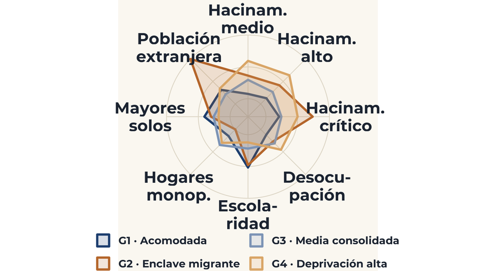

**G2 recibe un índice de 0.294: más bajo que G3 (0.387) y que G4 (0.496)**, pese a tener el 29.3 % de población extranjera y el 3.1 % de hacinamiento crítico, lo peor del país.

Cada grupo se nombra por **su fila en la tabla**. Y la estrella explica a G2: tiene escolaridad **alta** y pocos hogares monoparentales —dos de las cuatro variables del índice— y eso compensa al hacinamiento.

Comunas que **más zonas aportan** a cada grupo:  
**G1** Las Condes, Viña del Mar  
**G2** Santiago, Independencia, Iquique  
**G3** Valparaíso, Maipú  
**G4** Cerro Navia, La Pintana.

## 09 · CorrespondenciasTerritorio y tipo de carencia

- Mapa perceptual
- Tabla (perfiles)

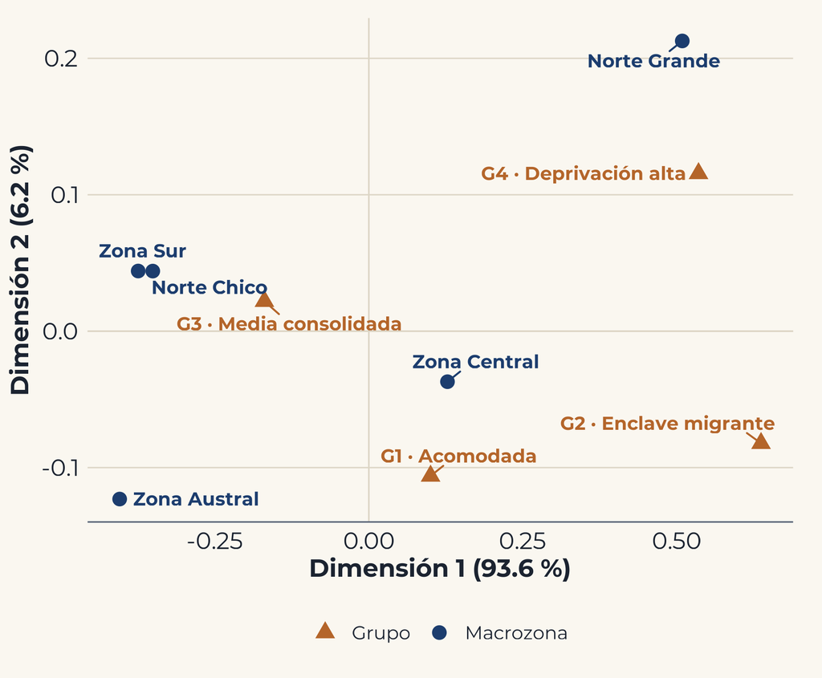

| Macrozona | G1 Acomodada | G2 Enclave Migrante | G3 Media Consolidada | G4 Deprivación Alta |
| --- | --- | --- | --- | --- |
| Norte Grande | 18,9 | 8,0 | 46,5 | 26,6 |
| Norte Chico | 16,4 | 1,1 | 79,0 | 3,4 |
| Zona Central | 24,2 | 5,6 | 57,1 | 13,2 |
| Zona Sur | 17,4 | 0,0 | 79,1 | 3,5 |
| Zona Austral | 23,6 | 0,0 | 76,4 | 0,0 |

H₀ macrozona y grupo son **independientes**

H₁ están asociados

$\chi^2_{12}=$ 354, $p$ < 2e-16 · inercia $=\chi^2/n=$ 0.073

Se rechaza H₀.  
El AC descompone ese $\chi^2$: 99.8 % en el plano.

Dimensión 1 · 93.6 % de la inercia Contrapone el **Norte Grande** —atraído por el enclave y por la deprivación alta— con la **Zona Sur** y la **Austral**.

34.6 %del Norte Grande en grupos críticos

3.5 %de la Zona Sur

Asociación clara, inercia baja El territorio **inclina** la composición de perfiles; no la determina.

Cercanía entre categorías de **distinta** variable = asociación;  
de la **misma** variable = similitud.

## 10 · Clasificación supervisada¿Puede el índice detectar el enclave?

Regresión logística · sensibilidad, especificidad y curva ROC

- Gráfico ROC
- Corte Óptimo
- Estricto (0.50)

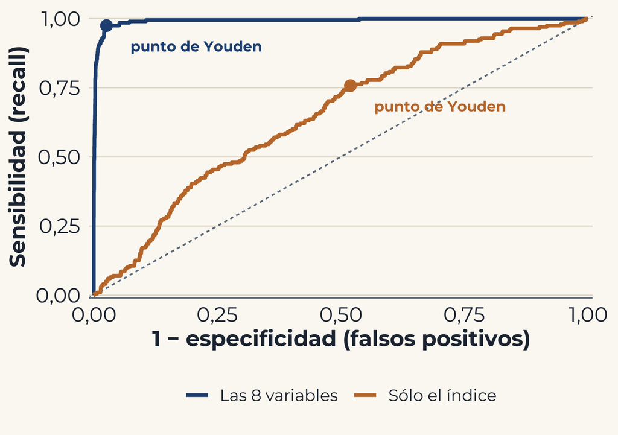

Corte de Youden

|  | Predice **G2** | Predice resto |
| --- | --- | --- |
| Es **G2** (198) | 193verd. positivos | 5falsos negativos |
| No es G2 (4.645) | 120falsos positivos | 4.525verd. negativos |

Sensibilidad **97.5%** · Especificidad **97.4%**  
Con **sólo el índice**: 150 aciertos y **2.414 falsos positivos**.

Corte estricto: prioriza evitar falsas alarmas

|  | Predice **G2** | Predice resto |
| --- | --- | --- |
| Es **G2** (198) | 164verd. positivos | 34falsos negativos |
| No es G2 (4.645) | 18falsos positivos | 4.627verd. negativos |

Sensibilidad **82.8%** · Especificidad **99.6%**  
Con **sólo el índice**: 0 aciertos y **0 falsos positivos**.

**El positivo es pertenecer a G2**, el enclave migrante: 198 de 4.843 zonas (4.1 %). La pregunta se vuelve binaria: *¿es esta zona parte del enclave?*

0.993AUC con las 8 variables

0.65AUC con sólo el índice

Sensibilidad 97.5 % y especificidad 97.4 % con las ocho. Con el índice, la especificidad cae a 48 %.

Hipótesis 2 respaldada El AUC no depende del umbral: no se arregla moviendo el corte. **La información no está en el índice.**

## 11 · IntegraciónLa cadena, en seis eslabones

1Un bloque no encaja0,52Va con población extranjera… pero ésta va con **más** escolaridad (+0,37).

2Hacen falta tres ejes75,6 %ACP y factorial, con supuestos distintos, dan la **misma** solución de tres ejes.

3El índice ve uno solo−0,337Su correlación con la CP2, que vale un cuarto de la varianza (con la CP1, 0,907).

4Hay un grupo invisible198Zonas con 29,3 % de extranjeros que el índice ubica **bajo** la periferia clásica.

5Nadie lo recupera0,650AUC para detectarlo con el índice; con las ocho variables, **0,993**.

6Todo pasa bajo la comuna64,6 %De la variabilidad de la CP1 es **intracomunal**: la escala es submunicipal.

## 12 · CierreConclusiones

- **La deprivación urbana chilena no es unidimensional.** Tres ejes incorrelacionados explican el 75.6 % de la estructura, y dos técnicas con supuestos distintos llegan a la misma solución.
- **El índice oficial mide bien, pero mide poco.** Captura la carencia clásica ($r =$ 0.907 con la CP1) y deja fuera una cuarta parte de la información.
- **Esa omisión tiene consecuencias concretas.** 198 zonas con 29.3 % de población extranjera y las peores condiciones de vivienda del país quedan **por debajo** de la periferia clásica. Ningún clasificador logra reconstruirlas desde el índice: el AUC cae de 0.993 a 0.65.
- **Y la política basada en promedios comunales opera sobre una ficción estadística.** El 64.6 % de la variabilidad ocurre **dentro** de cada comuna.

Medir la carencia con *un* número obliga a elegir *qué* carencia mirar.

Tres dimensiones, cuatro grupos y dos tercios de la variabilidad dentro de cada comuna. La evidencia sugiere que el próximo índice territorial chileno debería ser un vector, no un escalar.